# Linear algebra: Review

# Linear regression: review

Let's take the simple linear regression example from STS332 textbook (uploaded on brightspace;page 300; Table 6-1).

"As an illustration, consider the data in Table 6-1. In this table, y is the salt concentration (milligrams/liter) found in surface streams in a particular watershed and x is the percentage of the watershed area consisting of paved roads."

```python
%%writefile saltconcentration.tsv
#Observation	SaltConcentration	RoadwayArea
1	3.8	0.19
2	5.9	0.15
3	14.1	0.57
4	10.4	0.4
5	14.6	0.7
6	14.5	0.67
7	15.1	0.63
8	11.9	0.47
9	15.5	0.75
10	9.3	0.6
11	15.6	0.78
12	20.8	0.81
13	14.6	0.78
14	16.6	0.69
15	25.6	1.3
16	20.9	1.05
17	29.9	1.52
18	19.6	1.06
19	31.3	1.74
20	32.7	1.62
```

```
Writing saltconcentration.tsv
```

```python
# numpy can import text files separated by seprator like tab or comma
salt_concentration_data = np.loadtxt("saltconcentration.tsv")
salt_concentration_data
```

```
array([[ 1.  ,  3.8 ,  0.19],
       [ 2.  ,  5.9 ,  0.15],
       [ 3.  , 14.1 ,  0.57],
       [ 4.  , 10.4 ,  0.4 ],
       [ 5.  , 14.6 ,  0.7 ],
       [ 6.  , 14.5 ,  0.67],
       [ 7.  , 15.1 ,  0.63],
       [ 8.  , 11.9 ,  0.47],
       [ 9.  , 15.5 ,  0.75],
       [10.  ,  9.3 ,  0.6 ],
       [11.  , 15.6 ,  0.78],
       [12.  , 20.8 ,  0.81],
       [13.  , 14.6 ,  0.78],
       [14.  , 16.6 ,  0.69],
       [15.  , 25.6 ,  1.3 ],
       [16.  , 20.9 ,  1.05],
       [17.  , 29.9 ,  1.52],
       [18.  , 19.6 ,  1.06],
       [19.  , 31.3 ,  1.74],
       [20.  , 32.7 ,  1.62]])
```

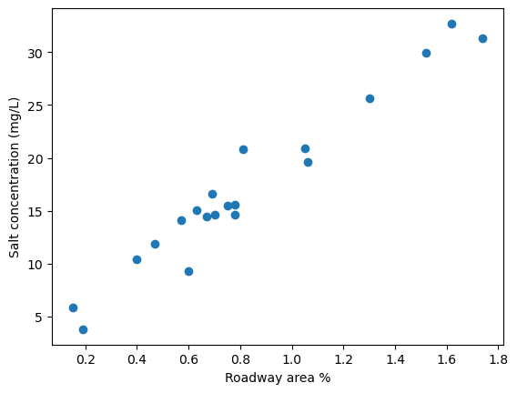

```python
# Plot the points
fig, ax = plt.subplots()
# Scatter plot using matplotlib
ax.scatter(salt_concentration_data[:, 2], salt_concentration_data[:, 1])
ax.set_xlabel(r"Roadway area %")
ax.set_ylabel(r"Salt concentration (mg/L)")
```

## Least squares regression

[figure not shown]

## Vectorization of Least square regression

### Two rules of vector derivatives

There are two conventions in vector derivatives:

1. Gradient convention
2. Jacobian convention

#### Gradient convention

#### Jacobian convention

#### Derivative of a linear function

#### Derivative of a quadratic function

### Back to Least square regression

```python
n = salt_concentration_data.shape[0]
bfx = salt_concentration_data[:, 2:3]
bfy = salt_concentration_data[:, 1:2]
bfX = np.hstack((bfx, np.ones((bfx.shape[0], 1))))
bfX
```

```
array([[0.19, 1.  ],
       [0.15, 1.  ],
       [0.57, 1.  ],
       [0.4 , 1.  ],
       [0.7 , 1.  ],
       [0.67, 1.  ],
       [0.63, 1.  ],
       [0.47, 1.  ],
       [0.75, 1.  ],
       [0.6 , 1.  ],
       [0.78, 1.  ],
       [0.81, 1.  ],
       [0.78, 1.  ],
       [0.69, 1.  ],
       [1.3 , 1.  ],
       [1.05, 1.  ],
       [1.52, 1.  ],
       [1.06, 1.  ],
       [1.74, 1.  ],
       [1.62, 1.  ]])
```

```python
bfm = np.linalg.inv(bfX.T @ bfX) @ bfX.T @ bfy
print(bfm)
bfm, *_ = np.linalg.lstsq(bfX, bfy, rcond=None)
print(bfm)
```

```
[[17.5466671 ]
 [ 2.67654631]]
[[17.5466671 ]
 [ 2.67654631]]
```

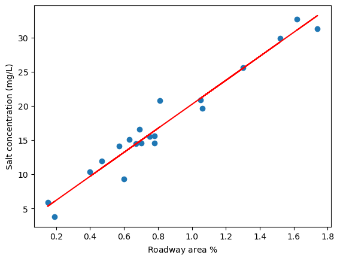

```python
m = bfm.flatten()[0]
c = bfm.flatten()[1]

# Plot the points
fig, ax = plt.subplots()
ax.scatter(salt_concentration_data[:, 2], salt_concentration_data[:, 1])
ax.set_xlabel(r"Roadway area $\%$")
ax.set_ylabel(r"Salt concentration (mg/L)")
x = salt_concentration_data[:, 2]
y = m * x + c
# Plot the points
ax.plot(x, y, 'r-') # the line
```

## Exercise 1

Derive the equations for least square linear regression when the equation of line is $\hat{\bfw}^\top \bfx + w_0 = 0$ instead of $y = mx + c$.

Hint: Convert the least square problem into equation of the form $\bfv^* = \arg~\min_{\bfv}\|\mathbf{L}\bfv\|^2$ such that $\bfv^\top \bfv = 1$. Solve by finding null space of $\mathbf{L}$. $\bfv$ lies in the nullspace of $\mathbf{L}$. The nullspace of $\mathbf{L}$ is the last eigenvector (corresponding to the smallest eigenvalue) of $\mathbf{L}^\top\mathbf{L}$.

The error $e(x_i, y_i) = (y - (mx + c))^2$ can be visualized as distance of observed point from the fit line parallel to y-axis. Draw the visual for the errors of the form: $e(\bfx_i) = (\hat{\bfw}^\top \bfx_i + w_0 - 0)^2$. You do not need to use matplotlib. You can draw by hand or editing software.